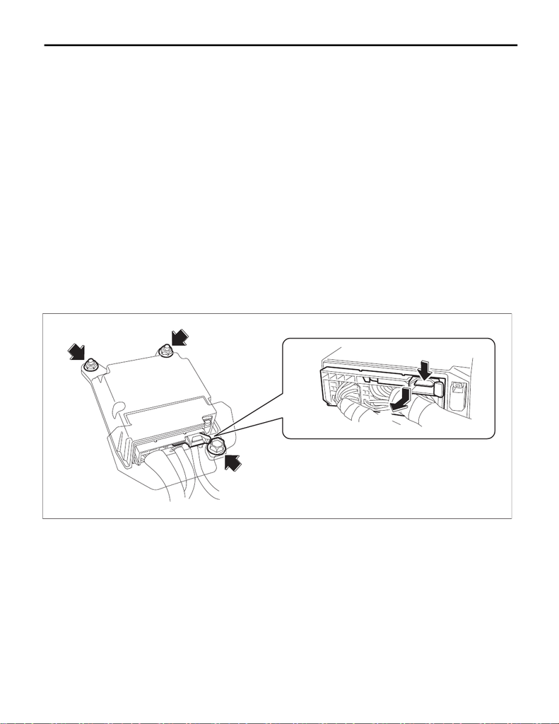

AB-48

Airbag Control Module

AIRBAG SYSTEM

9. Airbag Control Module

A: REMOVAL

CAUTION:

• Do not disassemble the airbag control module.

• If the airbag control module is deformed or if there is any trace of water on the module, replace the

airbag control module with a new one.

• Do not drop the airbag control module.

• After removal, keep the airbag control module on a dry, clean surface away from moisture, heat

and dust.

1) Turn the ignition switch to OFF.

2) Disconnect the ground cable from battery and wait for at least 60 seconds before starting work. <Ref. to

NT-5, BATTERY, NOTE, Note.>

NOTE:

• For models other than STI model, disconnect the ground terminal from battery sensor.

• On CVT models, shift the select lever into “D” before disconnecting the battery ground cable.

3) Remove the console box assembly and the cover - shift lever. <Ref. to EI-67, REMOVAL, Console Box.>

4) Remove the panel center assembly. <Ref. to EI-66, REMOVAL, Center Console.>

5) Remove the airbag control module.

(1) Disconnect the connector from airbag control module. <Ref. to AB-18, AIRBAG CONTROL MODULE,

PROCEDURE, Airbag Connector.>

(2) Remove the bolt and nuts and remove the airbag control module.

AB-02931

(1)

(2)

[figure not shown]

AB-49

Airbag Control Module

AIRBAG SYSTEM

B: INSTALLATION

1) Before installation, inspect the following items and replace any faulty part with a new part.

• Control module is deformed.

• Control module connector is damaged.

• Control module mounting bracket is damaged.

2) Install the airbag control module.

CAUTION:

Do not reuse the bolt and nut.

Always replace with the specified new bolts and nuts.

Tightening torque:

25 N·m (2.5 kgf-m, 18.4 ft-lb)

3) Install the panel center assembly.

4) Install the cover - shift lever and the console box assembly.

5) Connect the battery ground terminal. <Ref. to NT-5, BATTERY, NOTE, Note.>

NOTE:

For models other than STI model, connect the ground terminal to battery sensor.